# Assignment No 1

# Data Understanding and Exploratory Data Analysis

# Guidelines

1. Rename jupyter notebook as **rollnumber_firstname_lastname**.
2. You are only allowed to use pandas, numpy and seaborn libraries.
3. You are supposed to answer the question here on Jupyter notebook. Use markdown cells to answer the questions while use "Code" cells to write the code. You can double click on any markdown cell to edit it and press **shift+enter** to execute any cell.
4. Once finished, go to File menu and download the notebook as .html
5. Make sure all required figures and tables are visible in the HTML file.
6. Submit this HTML file. Note that it must follow the naming convention mentioned above.

# Import Libraries

```python
# Do not modify this cell

import pandas as pd
import numpy as np
import seaborn as sns
```

# Import Data

```python
# do not modify this cell

train_data = pd.read_csv('data/anneal.data', header=None,
                         names = ['shape','thick','width','length','oil', 'bore', 'packing', 'classes'],
                         sep= '\t')
```

```python
train_data_backup = train_data.copy()
train_data_backup.head(100)
train_data.isnull().sum()
```

```
shape        0
thick        0
width        0
length       0
oil        740
bore         0
packing    789
classes      0
dtype: int64
```

# Part 1: Filling missing (NaN) values. (8 questions, 5 marks each)

**We have loaded a dataset for you and it's first 10 rows are printed. All below experiments are to be performed on the variable "train_data".**

1. Identify and enlist numerical and categorical attributes.
2. Print summary statistics of the numerical attributes of the data (mean, std, min, 25%, 50%, 75%, max, counts).
3. Write a code below that prints total number of records and total number of attributes of this data.
4. Fill the missing values with using next valid observation. For example, for **oil** column, first 6 rows would be filled with value **Y**. This is known as "backward fill".
5. What problems would arise if you use "forward fill" instead?
6. Print summary statistics again and comment on the difference (before and after filling missing values).

**Enlist numerical and categorical attributes.**

> Numerical Attributes : thick,width, length Categorical Attributes: shape,oil,classes,bore,packing

Print summary statistics of the numerical attributes of the data (mean, std, min, 25%, 50%, 75%, max, counts).

```python
numerical = ['thick','width','length']
train_data[numerical].describe()
train_data.describe()
```

|  | thick | width | length | bore | packing |
| --- | --- | --- | --- | --- | --- |
| count | 798.000000 | 798.000000 | 798.000000 | 798.000000 | 9.000000 |
| mean | 1.181847 | 781.744361 | 1273.037594 | 28.195489 | 2.888889 |
| std | 0.861608 | 404.722346 | 1886.768139 | 124.811534 | 0.333333 |
| min | 0.250000 | 0.000000 | 0.000000 | 0.000000 | 2.000000 |
| 25% | 0.601000 | 609.900000 | 0.000000 | 0.000000 | 3.000000 |
| 50% | 0.800000 | 610.000000 | 611.000000 | 0.000000 | 3.000000 |
| 75% | 1.600000 | 1250.000000 | 762.000000 | 0.000000 | 3.000000 |
| max | 4.000000 | 1525.000000 | 4880.000000 | 600.000000 | 3.000000 |

```python
# Show number of records and number of attributes of the data above

train_data.info()
```

```
<class 'pandas.core.frame.DataFrame'>
RangeIndex: 798 entries, 0 to 797
Data columns (total 8 columns):
shape      798 non-null object
thick      798 non-null float64
width      798 non-null float64
length     798 non-null int64
oil        58 non-null object
bore       798 non-null int64
packing    9 non-null float64
classes    798 non-null object
dtypes: float64(3), int64(2), object(3)
memory usage: 50.0+ KB
```

Write a code below that prints total number of records and total number of attributes of this data.

```python
recs = len(train_data)
atts=(train_data.columns)
tot = len(atts)

print("Total records ", recs)
print("TAttributes ", atts)
print("Total number of Attributes ", tot )
```

```
Total records  798
TAttributes  Index(['shape', 'thick', 'width', 'length', 'oil', 'bore', 'packing',
       'classes'],
      dtype='object')
Total number of Attributes  8
```

```python
# Write code to perform backward fill for all columns. Show first 10 rows.
train_data.bfill(axis='rows',inplace=True)
train_data.head(10)
```

|  | shape | thick | width | length | oil | bore | packing | classes |
| --- | --- | --- | --- | --- | --- | --- | --- | --- |
| 0 | COIL | 0.700 | 610.0 | 0 | Y | 0 | 3.0 | 3 |
| 1 | COIL | 3.200 | 610.0 | 0 | Y | 0 | 3.0 | 3 |
| 2 | SHEET | 0.700 | 1300.0 | 762 | Y | 0 | 3.0 | 3 |
| 3 | COIL | 2.801 | 385.1 | 0 | Y | 0 | 3.0 | 3 |
| 4 | SHEET | 0.801 | 255.0 | 269 | Y | 0 | 3.0 | 3 |
| 5 | COIL | 1.600 | 610.0 | 0 | Y | 0 | 3.0 | 3 |
| 6 | SHEET | 0.699 | 610.0 | 4880 | Y | 0 | 3.0 | 3 |
| 7 | COIL | 3.300 | 152.0 | 0 | Y | 0 | 3.0 | 3 |
| 8 | COIL | 0.699 | 1320.0 | 0 | Y | 0 | 3.0 | 3 |
| 9 | SHEET | 1.000 | 1320.0 | 762 | Y | 0 | 3.0 | 3 |

# Convert this to a "Markdown" cell and answer the question 5.

What problems would arise if you use "forward fill" instead?

It depends on the dataset whether we should use forward fill or backward fill. If we use backward forward fill, we would have to wait till first non-null value in every column across the dataset. Our set is such that they appear later on. Using backward fill however, the first non-null value for columns with missing values appear early.

Print summary statistics again and comment on the difference (before and after filling missing values).

```python
print(train_data.describe())
print(train_data.isnull().sum())
```

```
            thick        width       length        bore     packing
count  798.000000   798.000000   798.000000  798.000000  769.000000
mean     1.181847   781.744361  1273.037594   28.195489    2.892068
std      0.861608   404.722346  1886.768139  124.811534    0.310497
min      0.250000     0.000000     0.000000    0.000000    2.000000
25%      0.601000   609.900000     0.000000    0.000000    3.000000
50%      0.800000   610.000000   611.000000    0.000000    3.000000
75%      1.600000  1250.000000   762.000000    0.000000    3.000000
max      4.000000  1525.000000  4880.000000  600.000000    3.000000
shape       0
thick       0
width       0
length      0
oil         4
bore        0
packing    29
classes     0
dtype: int64
```

Since missing values were only present in categorical variables, there is no difference in numerical attributes. However, number of missing values have gone down. Mean and std for packing have changed however, since it is a categorical variable, these values don't really have an interpretation.

1. Now use **train_data_backup** and fill missing values by taking mode of each column. Print summary statistics of numerical attributes and comment of the difference (between backward fill and mode fill).

```python
# Fill missing values of train_data_backup and print summary statistics.
t_mode = train_data_backup['packing'].mode()
t_mode = int(t_mode)
train_data_backup['packing'].fillna(t_mode,inplace=True)
o_mode = list(train_data_backup['oil'].mode())[0]
train_data_backup['oil'].fillna(o_mode,inplace=True)

#print(train_data_backup['thick'].describe())

#print(train_data_backup['width'].describe())

#print(train_data_backup['length'].describe())

train_data_backup.describe()
```

|  | thick | width | length | bore | packing |
| --- | --- | --- | --- | --- | --- |
| count | 798.000000 | 798.000000 | 798.000000 | 798.000000 | 798.000000 |
| mean | 1.181847 | 781.744361 | 1273.037594 | 28.195489 | 2.998747 |
| std | 0.861608 | 404.722346 | 1886.768139 | 124.811534 | 0.035400 |
| min | 0.250000 | 0.000000 | 0.000000 | 0.000000 | 2.000000 |
| 25% | 0.601000 | 609.900000 | 0.000000 | 0.000000 | 3.000000 |
| 50% | 0.800000 | 610.000000 | 611.000000 | 0.000000 | 3.000000 |
| 75% | 1.600000 | 1250.000000 | 762.000000 | 0.000000 | 3.000000 |
| max | 4.000000 | 1525.000000 | 4880.000000 | 600.000000 | 3.000000 |

7- Only values for 'packing' have changed (from the original dataset values). The mean hasn't changed much (increased by 0.109). This is because previously, mean was calculated over only non-NaN values. Now, it is being computed over all the values. It has increased because we've replaced NaN with the highest value in the respective column. However, it should be remembered that packing is a categorical variable so it's mean value will depend upon labels assigned to every category.

8 -Which method of filling missing values is desirable for this particular data and why?

Mode is better because because backward fill is an arbitrary choice because rows are not ordered in any way. Also, back/forward fill can often still leave missing values whereas mode ensures there will be no missing values as long as there is one value in the column that's not NaN. Aditionally, packing/oil are categorical variable so mode fill makes more sense than mean, which has no interpreation in categorical variables

# Part 2: Correlation, Covariance and Heatmaps (4 questions, 5 marks each)

**In this data, you are provided gender income data. Your job is to find correlation and covariance between attributes.**

```python
gender_data = pd.read_csv("data/gender_data.csv", sep = ',')
```

```python
gender_data.head()
```

|  | Gender | Age | Income | City |
| --- | --- | --- | --- | --- |
| 0 | F | 28 | 90000 | khi |
| 1 | F | 25 | 75000 | lhr |
| 2 | F | 22 | 50000 | lhr |
| 3 | M | 27 | 78000 | lhr |
| 4 | M | 22 | 50000 | lhr |

1. Identify "Binary Symmetric Attribute", "Numerical Continuous Attribute", "Numerical Discrete Attribute" and "Categorical Discrete Attribute".
2. Write a code to convert all categorical attributes to numerical attributes (you may use dictionary to map the values to integers).
3. Write code to calculate correlation matrix and visualize it using a heatmap. Note that if you have sucessfully converted all the attributes to numerical variables, you will get a 4x4 matrix. Comment on the results. In particularly, answer the following.
   1. Does the choice of city of employment makes an impact on the earning of a particular gender?
   2. Does income variable depends on age variable?
4. Write code to calculate covariance matrix and print it. Comment on the results. What does covariance signify with respect to this dataset?

**Write down the attributes you have identified.** **Binary Symmetric Attribute - Gender** **Numerical Continuous Attribute - Income** **Numerical Discrete Attribute - Age** **Categorical Discrete Attribute - City, Gender**

```python
# Code to convert attributes

gender_data['Gender'] = pd.Categorical(gender_data['Gender'])
dummies = pd.get_dummies(gender_data['Gender'],prefix = 'Gender')
new_gender_data = pd.concat([gender_data,dummies],axis=1)

gender_data['City'] = pd.Categorical(gender_data['City'])
city_dummies = pd.get_dummies(gender_data['City'],prefix = 'City')
new_data = pd.concat([new_gender_data,city_dummies],axis=1)
new_data.drop(['Gender','City'],axis=1)
```

|  | Age | Income | Gender_F | Gender_M | City_isb | City_khi | City_lhr |
| --- | --- | --- | --- | --- | --- | --- | --- |
| 0 | 28 | 90000 | 1 | 0 | 0 | 1 | 0 |
| 1 | 25 | 75000 | 1 | 0 | 0 | 0 | 1 |
| 2 | 22 | 50000 | 1 | 0 | 0 | 0 | 1 |
| 3 | 27 | 78000 | 0 | 1 | 0 | 0 | 1 |
| 4 | 22 | 50000 | 0 | 1 | 0 | 0 | 1 |
| 5 | 28 | 90000 | 0 | 1 | 0 | 0 | 1 |
| 6 | 28 | 90000 | 0 | 1 | 0 | 1 | 0 |
| 7 | 22 | 50000 | 0 | 1 | 0 | 1 | 0 |
| 8 | 27 | 76000 | 1 | 0 | 0 | 1 | 0 |
| 9 | 22 | 50000 | 1 | 0 | 1 | 0 | 0 |
| 10 | 28 | 90000 | 1 | 0 | 0 | 0 | 1 |
| 11 | 28 | 90000 | 0 | 1 | 0 | 0 | 1 |
| 12 | 26 | 75000 | 0 | 1 | 1 | 0 | 0 |
| 13 | 25 | 75000 | 1 | 0 | 1 | 0 | 0 |
| 14 | 25 | 75000 | 1 | 0 | 0 | 1 | 0 |
| 15 | 22 | 50000 | 0 | 1 | 0 | 1 | 0 |
| 16 | 25 | 75000 | 0 | 1 | 0 | 0 | 1 |
| 17 | 28 | 90000 | 0 | 1 | 1 | 0 | 0 |
| 18 | 28 | 90000 | 1 | 0 | 0 | 0 | 1 |
| 19 | 25 | 75000 | 1 | 0 | 0 | 0 | 1 |
| 20 | 28 | 90000 | 1 | 0 | 1 | 0 | 0 |
| 21 | 25 | 75000 | 1 | 0 | 1 | 0 | 0 |
| 22 | 22 | 50000 | 0 | 1 | 0 | 0 | 1 |
| 23 | 25 | 75000 | 0 | 1 | 0 | 0 | 1 |
| 24 | 25 | 75000 | 0 | 1 | 0 | 1 | 0 |
| 25 | 22 | 50000 | 1 | 0 | 0 | 1 | 0 |
| 26 | 28 | 90000 | 0 | 1 | 0 | 1 | 0 |
| 27 | 22 | 50000 | 1 | 0 | 0 | 0 | 1 |
| 28 | 25 | 75000 | 0 | 1 | 1 | 0 | 0 |
| 29 | 22 | 50000 | 1 | 0 | 1 | 0 | 0 |
| 30 | 27 | 76000 | 1 | 0 | 0 | 1 | 0 |
| 31 | 27 | 78000 | 0 | 1 | 0 | 0 | 1 |
| 32 | 28 | 90000 | 1 | 0 | 1 | 0 | 0 |
| 33 | 25 | 75000 | 0 | 1 | 1 | 0 | 0 |
| 34 | 22 | 50000 | 1 | 0 | 0 | 1 | 0 |
| 35 | 26 | 76000 | 1 | 0 | 0 | 0 | 1 |
| 36 | 26 | 75000 | 0 | 1 | 1 | 0 | 0 |
| 37 | 28 | 90000 | 1 | 0 | 0 | 1 | 0 |
| 38 | 25 | 75000 | 0 | 1 | 0 | 1 | 0 |
| 39 | 22 | 50000 | 0 | 1 | 1 | 0 | 0 |
| 40 | 25 | 75000 | 1 | 0 | 0 | 1 | 0 |
| 41 | 22 | 50000 | 0 | 1 | 1 | 0 | 0 |
| 42 | 26 | 76000 | 1 | 0 | 0 | 0 | 1 |
| 43 | 28 | 90000 | 0 | 1 | 1 | 0 | 0 |

```python
# Calculate correlation
correlation = new_data.corr()
print(correlation)
```

```
               Age    Income      Gender_F      Gender_M  City_isb  City_khi  \
Age       1.000000  0.977987  0.000000e+00  0.000000e+00 -0.038576  0.003858
Income    0.977987  1.000000 -3.023135e-03  3.023135e-03 -0.016227 -0.009736
Gender_F  0.000000 -0.003023  1.000000e+00 -1.000000e+00 -0.097590  0.097590
Gender_M  0.000000  0.003023 -1.000000e+00  1.000000e+00  0.097590 -0.097590
City_isb -0.038576 -0.016227 -9.759001e-02  9.759001e-02  1.000000 -0.466667
City_khi  0.003858 -0.009736  9.759001e-02 -9.759001e-02 -0.466667  1.000000
City_lhr  0.033616  0.025138  1.573593e-17 -1.573593e-17 -0.516398 -0.516398

              City_lhr
Age       3.361580e-02
Income    2.513803e-02
Gender_F  1.573593e-17
Gender_M -1.573593e-17
City_isb -5.163978e-01
City_khi -5.163978e-01
City_lhr  1.000000e+00
```

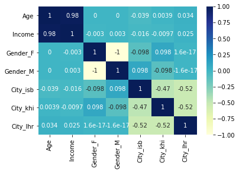

```python
# Heatmap Sample
ax = sns.heatmap(correlation, annot=True, cmap="YlGnBu")
```

**Comments on the Heatmap above**

a) Income and Gender are not very correlated ( Gender female and income are slightly (-0.003) negatively correlated. Correlation is only defined between two variabes. For income, we can see that it is positively(only slightly) correlated with lahore and negatively with Islamabad and Karachi. However, all these correlations are very weak (around 0).

b) Yes. As you grow older, income increases. Makes intuitive sense i.e more experience, savings, promotions etc

```python
# Caclulate covariance matrix and print it (4x4 matrix)

covariance = new_data.cov()
covariance
```

|  | Age | Income | Gender_F | Gender_M | City_isb | City_khi | City_lhr |
| --- | --- | --- | --- | --- | --- | --- | --- |
| Age | 5.412262 | 3.460465e+04 | 0.000000e+00 | 0.000000e+00 | -0.042283 | 0.004228 | 3.805497e-02 |
| Income | 34604.651163 | 2.313256e+08 | -2.325581e+01 | 2.325581e+01 | -116.279070 | -69.767442 | 1.860465e+02 |
| Gender_F | 0.000000 | -2.325581e+01 | 2.558140e-01 | -2.558140e-01 | -0.023256 | 0.023256 | 1.290957e-18 |
| Gender_M | 0.000000 | 2.325581e+01 | -2.558140e-01 | 2.558140e-01 | 0.023256 | -0.023256 | -1.290957e-18 |
| City_isb | -0.042283 | -1.162791e+02 | -2.325581e-02 | 2.325581e-02 | 0.221987 | -0.103594 | -1.183932e-01 |
| City_khi | 0.004228 | -6.976744e+01 | 2.325581e-02 | -2.325581e-02 | -0.103594 | 0.221987 | -1.183932e-01 |
| City_lhr | 0.038055 | 1.860465e+02 | 1.290957e-18 | -1.290957e-18 | -0.118393 | -0.118393 | 2.367865e-01 |

**Comments on the Covariance**